# Animal Form and Function (part 2)

## Things to Know (#s)

- **#Homeostasis**
- **#CircadianClocks**
- **#ThermoregulationBasics**

## Coordination and control of tissues and organs

- **Animal tissues and organs must be synced**
  - hunting predator: nose/ears → brain → muscles
- **Animals have 2 systems for stimulus response**
1. *Endocrine*: chemical signals released in bloodstream
2. *Nervous*: neurons transmit signals throughout body
- **Endocrine signalling via hormones**
  - many hormones with unique receptors
  - produced in cells/glands throughout the body
    - parts of the brain, gonads, pancreas
- **Nervous system signalling via electrical pathways**
  - nerve impulses travel to targeted destination

[figure not shown]

## Animals need to maintain their internal environment…

[figure not shown]

## Homeostasis: maintenance of internal balance for regulators

[figure not shown]

## Homeostasis: maintenance of internal balance

- **Animals exhibit *homeostasis* for many internal properties**
  - temperature, pH, blood glucose, etc.
- **Fluctuation in properties is a *stimulus***
- **Animal detect stimulus by a *receptor*, which triggers a *response***
  - returns variable to target value

[figure not shown]

## Homeostasis is maintained via negative feedbacks

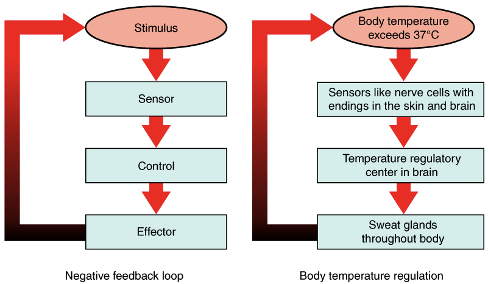

## Homeostasis for variables are not always constant

[figure not shown]

## Many human metabolic activities are on a circadian clock

[figure not shown]

## *Acclimation*: temporary adjustment to new environment

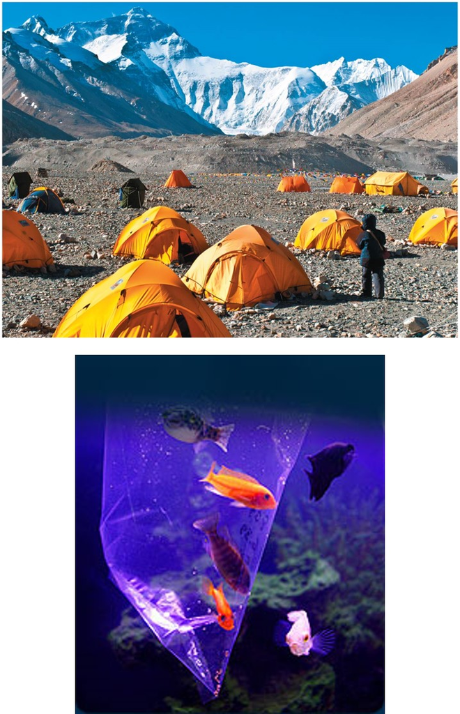

- **Animals often move into different environments**
  - changes in elevation, temperature, salinity, etc.
  - or endure seasons (without moving)
- **May need to adjust *homeostasis* to new conditions**
  - not permanent (or would be ‘adaptation’)
- **Example: mammals reach high altitude**
  - lower O<sub>2</sub> causes animals to breath rapid and deeply
  - more CO<sub>2</sub> is lost when exhaling, changing blood pH
  - over days, kidneys alter urine output to fix blood pH

## Form and function together: *Thermoregulation* case study

- **Thermoregulation:**
  - impacts enzyme activity, cellular fluids, biochemistry
- **Heat for thermoregulation can come from 2 sources**
1. Internal metabolism: *Endothermic*
2. External sources: *Ectothermic*
- **Endotherms can maintain temperatures in fluctuating environments**
  - ability to heat or cool themselves
- **Ectotherms adjust temperature via behaviors**
  - seeking shade or sun

[figure not shown]

## Ectotherms: Balancing heat loss and gain via behaviors

[figure not shown]

## Stop saying animals are ‘Cold’ or ‘Warm’ blooded

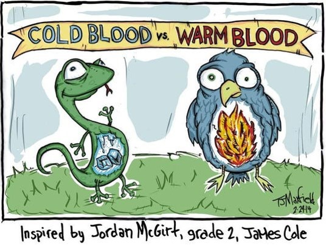

## Endotherms can produce internal heat: *Thermogenesis*

- **Endotherms bodies are constantly losing heat**
  - thermogenesis matches rates of heat loss
- **Thermogenesis increased by muscle activity**
  - moving
  - shivering
- **Shivering common in birds and flying insects**
  - ‘warming up’ flight muscles

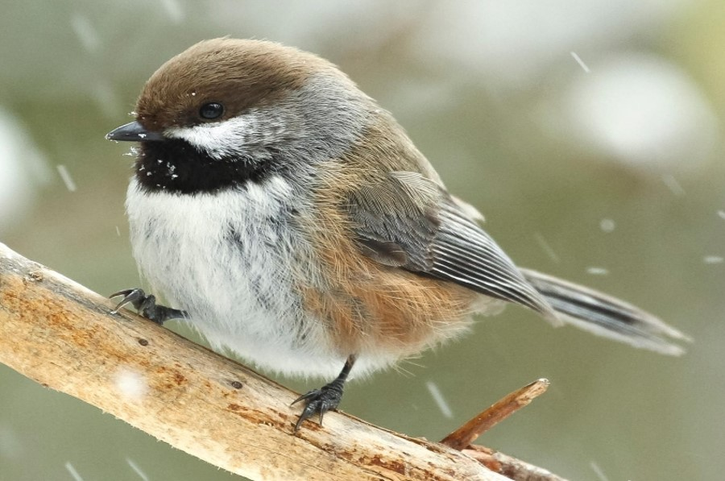

## Thermoregulation: Insulation reduces heat loss

- **Insulation reduces flow of heat**
  - fur, feathers, fat, oils
  - important for mammals and birds
- **Insulation may be altered**
  - raising hair or feathers when cold
  - goose bumps in humans!!!
- **Insulation vital for marine mammals**
  - water colder than body core
  - heat transfer faster in water than air

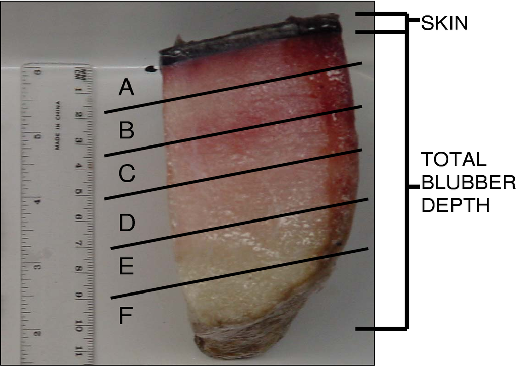

## Thermoregulation: Circulatory Responses

- **Animals can alter blood flow when temperatures change**
  - between internal body and skin
- **Blood vessels can relax, making them wider**
  - increases blood flow near skin to release heat
- **Blood vessels can also constrict**
  - reduces blood flow and prevents heat loss

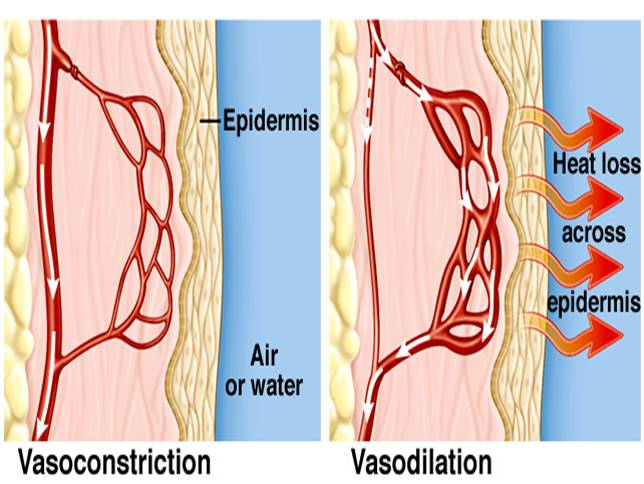

## Counter-current heat exchange

**Birds, mammals, sharks, insects often transfer heat between fluids moving in opposite directions**

**Arteries and veins located near each other**

**Heat transferred from warm blood (artery) to cold blood (vein) returning from extremities**

[figure not shown]

## Thermoregulation: Evaporative cooling (sweat glands)

**In some mammals, the nervous system stimulates sweat glands to secrete water to the skin surface, where it cools the body by evaporation**

[figure not shown]

## Thermoregulation: Social behavior

- **Group mechanisms to heat or cool**
  - Huddling for warmth
  - Fanning to cool
- **Emperor Penguins**
  - dark plumage facing out
  - overlapping feathers
  - shivering
  - fat insulation
  - feet tipped up
- **Social thermoregulation common in bees**

[figure not shown]

## The *hypothalamus* is the mammal thermostat

[figure not shown]

[figure not shown]